# 6.淺談影像識別_Q slides

## 淺談影像識別

### Da-Wei Chiang

## 大綱

- 何謂`OpenCV`
- `OpenCV Basic`
- 影像基本概念
- 人臉辨識

## 何謂`OpenCV`

- OpenCV全名`Open Source Computer Vision Library`是由`Intel`開發的模組
- 其主要應用於`電腦視覺`、`影像處理...`等圖像行領域

## `OpenCV Basic`

## `OpenCV`安裝

```
pip install opencv-python  #安裝

import cv2  #引用
```

## 載入圖片

```
#方法一
image_Variable = cv2.imread(image_path)
cv2.imshow('img', image_Variable)
cv2.waitKey(0)
cv2.destroyAllWindows()
cv2.waitKey(1)   #OpenCV bug
#方法二
image_Variable = cv2.imread(image_path)
image_Variable = image_Variable[:,:,::-1]
plt.imshow(image_Variable)
plt.show()
```

```python
# 範例

import cv2
from  matplotlib import pyplot as plt

image = cv2.imread('6.悟空.jpg')
cv2.imshow('img', image)
cv2.waitKey(0)
cv2.destroyAllWindows()
cv2.waitKey(1)
```

```
-1
```

```python
# 範例

import cv2
from  matplotlib import pyplot as plt

image = cv2.imread('6.悟空.jpg', 0)
cv2.imwrite('./悟空灰階.jpg', image)
```

```
True
```

## 練習

- 請自行抓取一張圖片, 並透過`OpenCV`讀取圖片

## 影像基本概念

- 黑白影像
- 灰階影像
- 彩色影像

## 黑白(位元)影像介紹

- 黑白影像是由`0`或`1`的位元組所構成, 我們稱為位元表示法
  - `0`表示為黑色、`1`表示為白色
- 影像中每一格我們稱之為像數`pixel`(如下圖所示)
- 黑白影像的缺點
  - 無法很細緻的呈現一張圖片

## 黑白(位元)影像介紹

[figure not shown]

## 灰階(`GRAY`)影像

- 一種黑白影像, 但在黑與白中多了很多灰階色彩.(如下圖所示)
  - `0`表示純黑色、`255`表示白色

[figure not shown]

## 彩色(`RGB`)影像

- `R(Red)、G(Green)、B(Blue)`為色彩的三原色, 是構成彩色圖像的基本通道`(Channel)`
- `RGB`中每個`Channel`的值皆介於`0 ~ 255`之間
- 圖片中的每個像素點皆由三個`Channel`所構成
- [網路調色盤](https://materialui.co/color-picker)

## `Open CV`的彩色影像

- 基本彩色圖學所使用的皆為`RGB`色彩影像, 但`OpenCV`的`Channel`順序為`BGR`

## `Open CV`圖像屬性

```python
# 範例

import cv2
from  matplotlib import pyplot as plt

image = cv2.imread('6.悟空.jpg')
print(type(image))
print(image.shape)   #高(x座標):1179px, 寬(y座標):872px, Channel:3
print(image.dtype)   #8位元無號整數
print(image)
```

```
<class 'numpy.ndarray'>
(1179, 872, 3)
uint8
[[[255 255 255]
  [255 255 255]
  [255 255 255]
  ...
  [255 255 255]
  [255 255 255]
  [255 255 255]]

 [[255 255 255]
  [255 255 255]
  [255 255 255]
  ...
  [255 255 255]
  [255 255 255]
  [255 255 255]]

 [[255 255 255]
  [255 255 255]
  [255 255 255]
  ...
  [255 255 255]
  [255 255 255]
  [255 255 255]]

 ...

 [[255 255 255]
  [255 255 255]
  [255 255 255]
  ...
  [255 255 255]
  [255 255 255]
  [255 255 255]]

 [[255 255 255]
  [255 255 255]
  [255 255 255]
  ...
  [255 255 255]
  [255 255 255]
  [255 255 255]]

 [[255 255 255]
  [255 255 255]
  [255 255 255]
  ...
  [255 255 255]
  [255 255 255]
  [255 255 255]]]
```

## 練習

- 自行產生一張其大小為300乘300全紅的圖片

## 繪圖

```
cv2.line(image_Variable, start, end, color, width)  #畫線
cv2.rectangle(image_Variable, start, end, color, width(cv2.FILLED))
cv2.circle(image_Variable, center, radius, color, width(cv2.FILLED))
##參數說明
image_Variable : 要繪製的圖
start : 開始的點位置
end : 結束的點位置
color : 線的顏色
width : 線的粗細
center : 圓心位置
radius : 半徑
cv2.FILLED : 粗細可改為全部填滿顏色
```

```
Clipping input data to the valid range for imshow with RGB data ([0..1] for floats or [0..255] for integers).
```

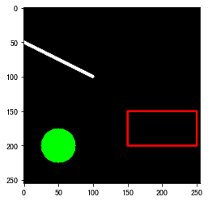

```python
## 範例
import cv2
import numpy as np
img = np.zeros((255, 255, 3))
cv2.line(img, (0, 50), (100, 100), (255, 255, 255), 4)
cv2.rectangle(img, (150, 150), (250, 200), (255, 0, 0), 2)
cv2.circle(img, (50, 200), 25, (0, 255, 0), cv2.FILLED)
plt.imshow(img)
plt.show()
```

## 練習

- 請產生一張長寬為255乘255的黑色圖片
- 並在這張圖片打一個大叉叉(左上到右下及右上到左下的線)
- 在圖片中心打一個全紅的正方形

## 人臉辨識

- 引用`OpenCV`[模型](https://github.com/opencv/opencv/tree/4.x/data/haarcascades)

## 模型引用與偵測

```
model_Variable = cv2.CascadeClassifier(model_path)
Rect_Para_Variable = model_Variable.detectMultiScale(image_Variable, 放大倍數, 偵測次數)
## 參數說明
```

```
1
62
68
192
192
```

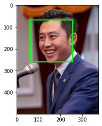

```python
## 範例
import cv2
from  matplotlib import pyplot as plt

image = cv2.imread('林智堅.jpg')
#image = cv2.imread('pose.jpg')
face_model = cv2.CascadeClassifier('face.xml')
faceRect = face_model.detectMultiScale(image, 2, 2)
print(len(faceRect))

for (x, y, w, h) in faceRect:
    print(x)
    print(y)
    print(w)
    print(h)
    cv2.rectangle(image, (x, y), (x+w, y+h), (0, 255, 0), 4)
image = image[:,:,::-1]
plt.imshow(image)
plt.show()
```

## 練習

- 請自行練習人臉辨識